# Introduction to Data Science 11372 & 11516 G

Tutorial / Laboratories - Week 12

Welcome to the tutorials and practical laboratory for **Introduction to Data Science**.

# Objectives

By the end of this tutorial, it is expected that you:

1. understand the correlation concept and can use it to check the linear relationship between the variables.
2. have the ability to compute and visualise the correlation values using R.

# Correlation

It is a statistical measure that can be used to measure the dependency/relationship between variables in a dataset. Moreover, it is a method that can be used to test the impact of changing set of variables (*i.e.*, explanatory) on another set of variables (*i.e.* response).

**The correlation coefficient has the following properties**:

1. The magnitude (absolute value) of the correlation coefficient represents the strength of the linear relationship between the explanatory and the response variables and its range is between -1 and 1.
2. The sign of the correlation coefficient indicates the direction of the relationship between the variables.
3. The correlation coefficient is unitless, *i.e.*, the value will stay very similar even with scaling or normalising any of the variables.

**Prerequisites**

Please download the “Advertising.csv” file from the contents of week 11’s module on Canvas and put it in your working directory.

# Exercises

## Exercise 1

1. Read the data from the “advertising.csv” file and get yourself familiar with the included variables.
2. Remove the un-named data variable(s), if any
3. Check the statistical summary of the “sales” variable (*hint:* you can use the summary function)
4. How about using the *summarise()* function?

## Exercise 2

Based on the previous exercise, complete the following tasks:

1. Plot scatter plots between the sales and each of the other variables in the data.
2. Add a regression line using `stat_smooth(method = lm)` to the previous plots? What does `lm` provide?
3. Compute the correlation between sales variable and each of the other variables independently, using `cor(var1, var2)` function.
4. Generate the correlation matrix for all the variables together.
5. Visualise the correlation matrix using `ggcorr(…)` function, by replacing `…` with the data frame.

## Exercise 3

We can also use the correlation matrix to test the linear relationship between variables, using `cor.test(var1, var2, method)`, where `method` can be “*Pearson*”, “*Spearman*”, etc.

1. Use the `cor.test` function to test the estimated correlation between sales and TV variables.
2. How would you interpret the *p-value* and *estimate* values?
3. Can you extract the *p-value* and *estimate* coefficients from the output of the correlation test?

## Exercise 4 - Generating code for a given plot

1. Please download “weather.csv” data from the contents of week 11’)’s module.
2. Given these data, can you write the code to generate the following plot? What are the steps would you follow?

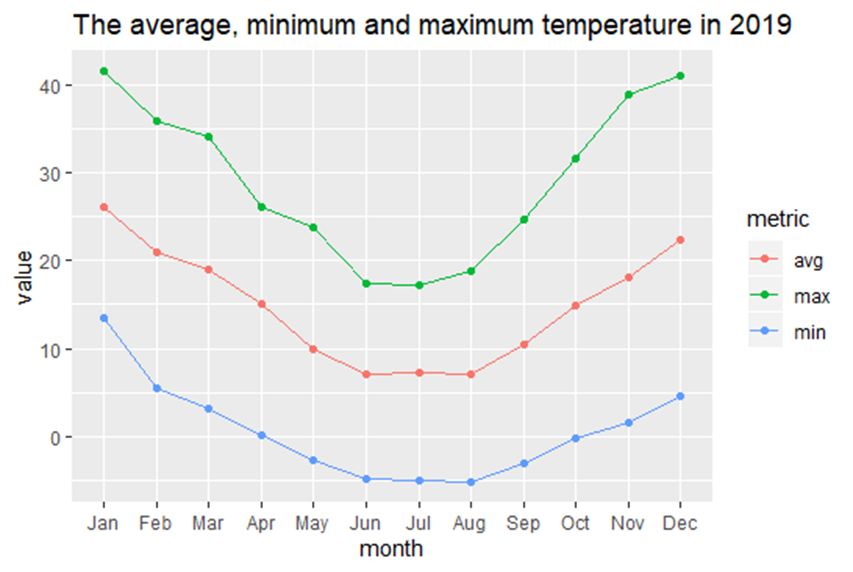